# Praca domowa 2

Imię Nazwisko - Piotr Utkowski

## Dane

Dane wykorzystane w Pracy domowej 2 są związane z kampaniami marketingu bezpośredniego portugalskiej instytucji bankowej. Kampanie marketingowe opierały się na rozmowach telefonicznych. Często wymagany był więcej niż jeden kontakt z tym samym klientem, aby uzyskać dostęp do tego, czy produkt (lokata bankowa) zostanie (lub nie) subskrybowany. Opis wszystkich kolumn znajduje się również w pliku `README.md`.

#### Dane klienta banku

| Zmienna | Opis |
| --- | --- |
| **age** | wiek |
| **job** : admin., unknown, unemployed, management, housemaid, entrepreneur, student, blue-collar, self-employed, retired, technician, services | administrator, nieznany, bezrobotny, kierownictwo, pokojówka, przedsiębiorca, student, pracownik fizyczny, samozatrudniony, emeryt, technik, usługi |
| **marital** : married, divorced, single; note: divorced means divorced or widowed) | żonaty/zamężna, rozwiedzion_, kawaler/panna; uwaga: rozwiedzion_ oznacza rozwiedzion_ lub owdowiał_ |
| **education** : unknown, secondary, primary, tertiary | nieznane, średnie, podstawowe, wyższe |
| **default** : yes, no | czy kredyt jest niespłacany : tak, nie |
| **balance** : average yearly balance, in euros | średnie roczne saldo w euro |
| **housing** : has housing loan? yes, no | czy posiada kredyt mieszkaniowy? tak, nie |
| **loan** : has personal loan? yes, no | ma pożyczkę osobistą? tak, nie |

#### Dane związane z ostatnim kontaktem w bieżącej kampanii

| Zmienna | Opis |
| --- | --- |
| **contact** : unknown, telephone, cellular | nieznany, telefon, komórkowy |
| **day** : last contact day of the month | dzień miesiąca ostatniego kontaktu |
| **month** : last contact month of year, jan, feb, mar, …, nov, dec | miesiąc ostatniego kontaktu w roku, styczeń, luty, marzec, …, listopad, grudzień |
| **duration** : last contact duration, in seconds | czas trwania ostatniego kontaktu w sekundach |

## Zadanie 1

Weźmy pod uwagę zawody (`job`) klientów banku. Który zawód zacząco wyróżnia się w posiadaniu kredytu mieszkaniowego lub pożyczki osobistej?

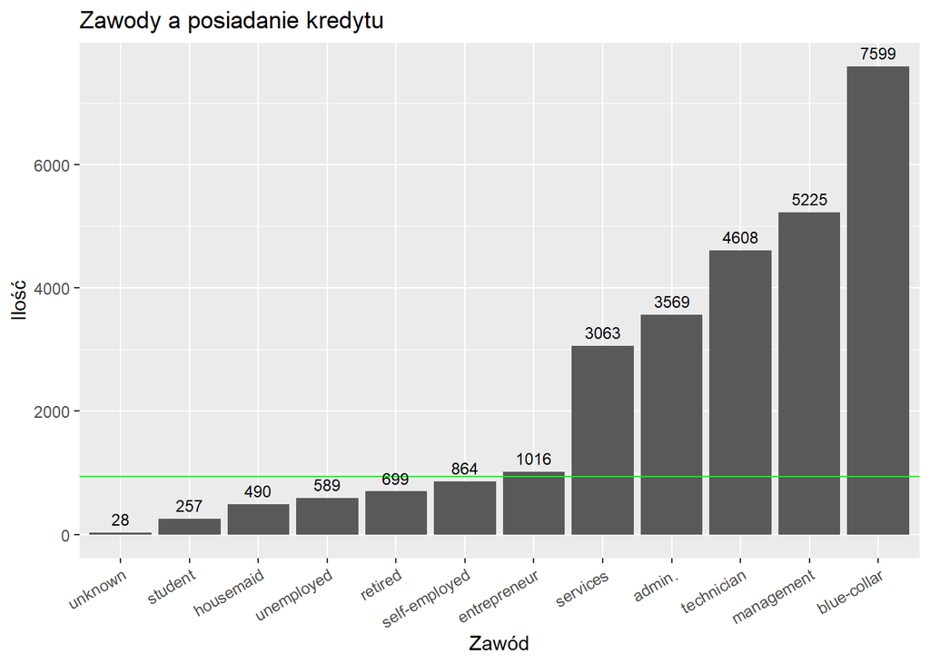

```r
tmp <- df %>%
  filter(housing == 'yes' | loan =='yes' ) %>%
  group_by(job) %>%
  summarise(n= n())
mediana <- median(tmp$n)


df %>%
  filter(housing == 'yes' | loan =='yes' ) %>%
  group_by(job) %>%
  summarise(n= n()) %>%
  arrange(desc(n)) %>%
  ggplot(aes(x=forcats:: fct_reorder(job, n), y=n))+
  geom_bar(stat="identity")+
  xlab("Zawód")+
  ylab("Ilość")+
  scale_x_discrete(guide = guide_axis(angle = 30))+
  geom_hline(yintercept = mediana, color = 'green')+
  geom_text(aes(label = n), vjust = -0.6, color = "black", size = 3)+
  ggtitle("Zawody a posiadanie kredytu")
```

**Komentarz:** Można zauważyć, że osoby z zawodów: usługi, administrator, technik, kierownictwo, pracownik fizyczny górują nad pozostałymi zawodami, jednak to pracownicy fizyczni znacząco wyróżniają się na tle osób z innych zawodów.

## Zadanie 2

Wybierając klientów, którzy mają nieznany sposób kontaktu (`contact`). Jak rozkłada się ich wiek w podziale na status związku?

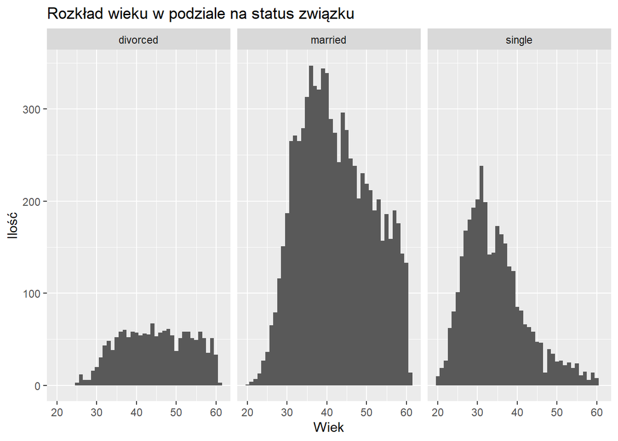

```r
df %>%
  filter(contact == 'unknown') %>%
  ggplot(aes(x= age))+
  geom_histogram(binwidth = 1)+
  facet_grid(~marital)+
  ggtitle("Rozkład wieku w podziale na status związku")+
  xlab("Wiek")+
  ylab("Ilość")
```

**Komentarz:** Wiek osób rozwiedzonych rozkłada się (w przybliżeniu) równomiernie, skok następuje po 30 roku życia. Dla osób żonatych/zamężnych wiek skupia się w pobliżu 35, co może wynikać z kosztów utrzymania rodziny (dzieci, większe mieszkanie, samochód). Dla osób będących singlami wiek skupia się w pobliżu 30, co może wynikać z przygotowań do zawarcia związku.

## Zadanie 3

Jaka jest różnica pomiędzy średnim rocznym saldem w euro w zależności od wykształcenia i tego czy kredyt jest niespłacany?

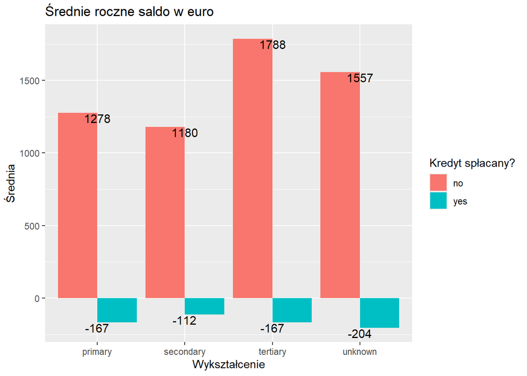

```r
tmp <- mean(df$balance)
df %>%
  group_by(education, default) %>%
  summarise(srednia=mean(balance)) %>%
  ggplot(aes(x=education, y=srednia))+
  geom_bar(stat = "identity",position = "dodge", aes(fill=default))+
  geom_text(aes(label = round(srednia)), color = "black", size = 4, vjust=1.1)+
  labs(title = "Średnie roczne saldo w euro",
       x = "Wykształcenie", y = "Średnia", fill = "Kredyt spłacany?")
```

## Zadanie 4

Czy dzień i miesiąc kontaktu z klientem ma wpływ na średni czas trwania rozmowy w stosunku do średniego czasu trwania rozmowy?

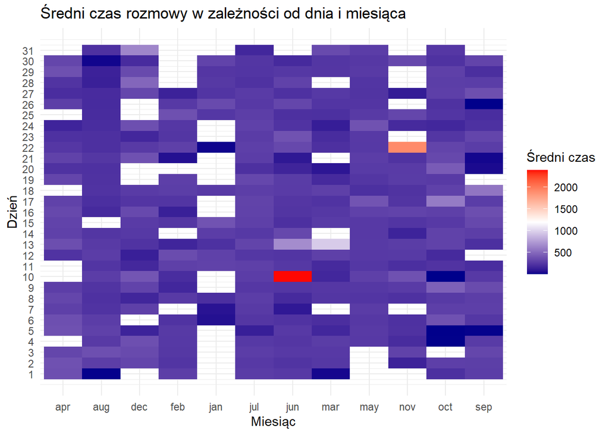

```r
df %>%
  group_by(month, day) %>%
  summarise(sredni_czas = mean(duration, na.rm = TRUE)) %>%
  ggplot(aes(x= month, y=day, fill = sredni_czas))+
  geom_tile() +
  scale_fill_gradient2(low = 'darkblue',
                       high = 'red',
                       midpoint = 1200)+
  scale_y_continuous(breaks = seq(1, 31, by = 1))+
  labs(title = "Średni czas rozmowy w zależności od dnia i miesiąca",
       x = "Miesiąc", y = "Dzień", fill = "Średni czas") +
  theme_minimal()
```

**Komentarz:** Nie ma zauważalnego wpływu dnia i miesiąca kontaktu z klientem na średni czas trwania rozmowy, jednak widać znaczący wzrost średniego czasu trwania rozmowy 10 czerwca i 22 listopada.

## Zadanie 5

Czy jest zależnośc pomiędzy wiekiem klientów a ich średnim rocznym saldzie w euro w podziale na stopień wykształcenia?

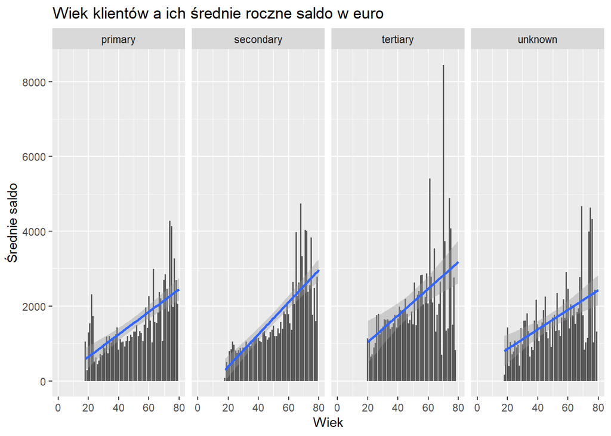

```r
df %>%
  group_by(education, age) %>%
  summarise(srednia=mean(balance)) %>%
  ggplot(aes(x=age, y=srednia))+
  geom_bar(stat="identity")+
  geom_smooth(method = "lm", se = TRUE, linetype = "solid") +
  scale_x_continuous(breaks = seq(0, 100, by = 10))+
  xlim(0,80)+ #zmnniejszyłem zakres na osi by łatwiej było postawić wnioski
  facet_grid(~education)+
  ggtitle("Wiek klientów a ich średnie roczne saldo w euro")+
  xlab("Wiek")+
  ylab("Średnie saldo")
```

**Komentarz:** Można zauważyć, że razem z wiekiem klientów rośnie ich średnie roczne saldo w euro. Wśród osób z wykształceniem średnim tempo wzrostu jest najszybsze, a wśród osób z wykształceniem nieznanym tempo jest najwolniejsze w porównaniu do osób z innym poziomem wykształcenia.

## Zadanie 6

Rozważmy osoby, które są bezrobotne albo ich zawód jest nieznany. Czy procent osób, które są bezrobotne i nie spłacają kredytu jest większy od procenta osób o nieznanym zawodzie i nie spłacanym kredycie? Jaki typ kredytu jest (przez te osoby) najczęściej niespłacany?

```r
tmp <- df %>%
  count()

tmp_df<-df %>%
  filter(job=='unknown' | job=='unemployed') %>%
  filter(default=='no') %>%
  group_by(job) %>%
  summarise(procent = 100*n()/tmp)


if(tmp_df$procent[tmp_df$job=='unemployed',] > tmp_df$procent[tmp_df$job=='unknown',]){
  print('TAK')
}else(print('NIE'))
```

```
## [1] "TAK"
```

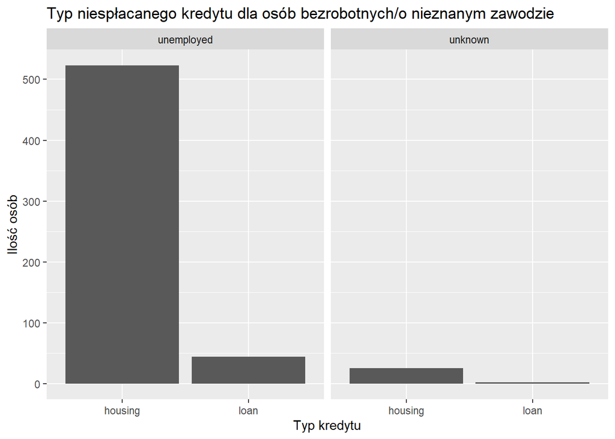

```r
df %>%
  filter(job=='unemployed' | job=='unknown') %>%
  filter(default == 'no') %>%
  mutate(typ_kredytu = case_when(housing=='yes' ~ 'housing',
                                 loan=='yes'~ 'loan')) %>%
  filter(!is.na(typ_kredytu)) %>% #NA pojawia się bo są osoby które tylko kontaktowały się z bankiema nie mają tam kredytu ani pożyczki
  ggplot(aes(x=typ_kredytu))+
  geom_bar()+
  facet_grid(~job)+
  ggtitle("Typ niespłacanego kredytu dla osób bezrobotnych/o nieznanym zawodzie")+
  xlab("Typ kredytu")+
  ylab("Ilość osób")
```